# 工程化学 · 电极电势与能斯特方程 · 电极电势的应用

刘训臣

山东科技大学 机械电子工程学院

# 课时 1 · 电极电势与能斯特方程

- 电极电势的产生
- 标准电极电势表
- 电动势与 Gibbs 自由能
- 能斯特方程
- 浓度与分压的影响
- **拓展专题（选讲）**：为什么电极电势是相对值？能斯特方程从哪里来（浓缩两页，细节见教学论文）

# 电极电势的产生

- 金属-溶液界面形成**双电层**，产生电势差
- 电极电势：该电极与标准氢电极（SHE，$E^\circ = 0$）组成的电池电动势
- 但界面电势其实分**三层**——内电势、外电势、表面电势，电压表只能测到其中一部分

# 电极电势与机械制造、材料

- **电解抛光、电化学加工**：机械制造中的精密成形
- **电沉积镀层、阳极氧化**：材料表面处理
- **腐蚀与防护**：零部件的失效与保护
- **化学电源与新能源电池**：电动化时代的动力来源
- 学完本讲：能用电极电势与能斯特方程分析这些应用

# 拓展专题（选讲）· 为什么电极电势是相对值？

- 伽伐尼/伏打之争（1800 年伏打电堆）开启了电化学，“界面电势”由此进入科学
- 界面电势分三层：**内电势** $\varphi$（伽伐尼电势）、**外电势** $\psi$（伏打电势）、**表面电势** $\chi$

$$\varphi = \psi + \chi$$

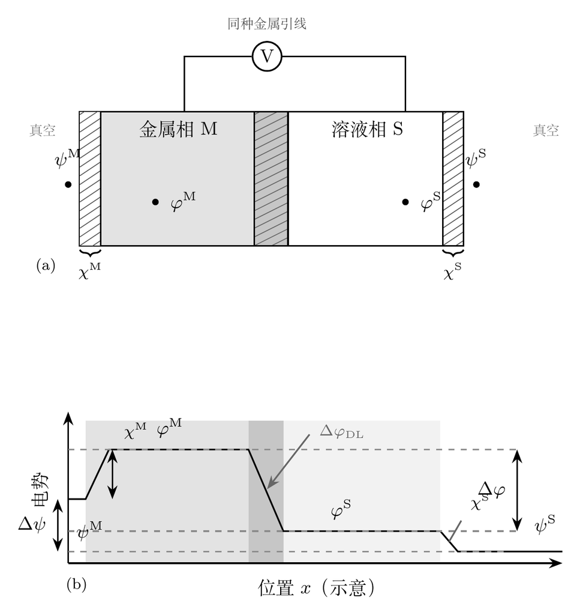

- 电压表两根引线是同种金属，只能传递**电子电化学势差** → 只能测伏打电势差 $\Delta\psi$
- 表面偶极项 $\chi$ 传不出来 → 含 $\chi$ 的内电势差测不到 → **电极电势只能是相对值**（SHE 定为 0）
- 常见误解是”测量会扰动体系”；真正原因是原理性的（$\chi$ 不可分离），与”Gibbs 能绝对值不可知、只能测变化量”同理

# 标准电极电势表

$$\text{Zn}^{2+} + 2e^- \rightleftharpoons \text{Zn}, \qquad E^\circ = -0.76\,\text{V}$$

$$\text{Cu}^{2+} + 2e^- \rightleftharpoons \text{Cu}, \qquad E^\circ = +0.34\,\text{V}$$

- $E^\circ$ 越大，氧化态越易得电子（氧化剂越强）

# 电动势与 Gibbs 自由能

$$\Delta_rG = -nFE$$

- $n$：转移电子数；$F = 96485\,\text{C/mol}$
- $E > 0$：反应自发；$E < 0$：非自发

# 能斯特方程

$$E = E^\circ - \frac{RT}{nF}\ln Q$$

25 °C 时：

$$E = E^\circ - \frac{0.0592}{n}\lg Q$$

# 浓度与分压的影响

- 增大氧化态浓度/分压 → $E$ 增大
- 增大还原态浓度/分压 → $E$ 减小
- 例：$\text{pH}$ 影响含 $\text{H}^+$ 电对的电势（高锰酸钾、重铬酸钾）

# 拓展专题（选讲）· 能斯特方程从哪里来

- 大一课堂用**教材简法**（热力学法）：$\Delta_rG = -nFE$，一步得到能斯特方程
- 严格推导走**电化学势法**（物化教材星号内容，研究生阶段展开），三步：
  1. 电化学势平衡 → 单电极内电势差 $\Delta\varphi$（如 $\Delta\varphi_{\mathrm{Zn}}$）
  2. 电子平衡 → 可测电动势 $E = \psi^{\mathrm{Cu}}-\psi^{\mathrm{Zn}}$（伏打电势差）
  3. 两电极相减**差一个常数**：$\Delta\varphi_{\mathrm{Cu}}-\Delta\varphi_{\mathrm{Zn}} = E + C_\chi$，$C_\chi$（表面偶极项之差）并入 $E^\circ$

$$E = E^\circ - \frac{RT}{nF}\ln Q$$

- 教材直接写 $E=\Delta\varphi_{\mathrm{Cu}}-\Delta\varphi_{\mathrm{Zn}}$ 是简写，结果不变
- 特殊体系（高温熔盐、固态电解质、非水溶剂）的推广留给研究生课程
- 课堂只给框架与问题，细节课后用 AI 反复追问自学；用思考题检验内化
- 细节见教学论文《电极电势与能斯特方程：界面电势的层次、可测性与推导》（刘训臣、崔淇鑫、徐义轩）

# 课时 2 · 电极电势的应用

- 判断氧化剂与还原剂的强弱
- 判断反应方向与限度
- 例题

# 判断氧化剂与还原剂的强弱

- $E^\circ$ 大的电对：氧化态是强氧化剂
- $E^\circ$ 小的电对：还原态是强还原剂
- 例：$E^\circ(\text{F}_2/\text{F}^-) > E^\circ(\text{O}_2/\text{OH}^-) > E^\circ(\text{Na}^+/\text{Na})$

# 判断反应方向与限度

$$E = E_+ - E_-$$

- $E > 0$：正向自发
- 平衡时 $E = 0$；25 °C 下

$$\lg K^\circ = \frac{nE^\circ}{0.0592}$$

# 例题

计算 $\text{Zn}^{2+}$ 浓度为 0.010 mol/L 时锌电极的电势（$E^\circ = -0.76\,\text{V}$）：

$$E = -0.76 + \frac{0.0592}{2}\lg 0.010 = -0.82\,\text{V}$$

# 常见误解（自测）

1. 把伽伐尼电势当成电压表能读出的量
2. 把电压表读数当成电极的”绝对电势”
3. 把零电荷电位理解成”电极不带电、电势为零”
4. 把”内电势不可测”归因于”测量扰动”
5. 把表面电势 $\chi$ 与双电层电势差混为一谈
6. 把”电动势 = 两电极内电势差之差”当成严格等式

# 思考题

1. 把一块铜电极接地后，它的电极电势会改变吗？
2. 用同种金属引线连接两块金属，电压表读数是什么？换成两根不同金属呢？
3. 零电荷电位处，电极的”绝对电势”为零吗？
4. 为什么”插入电极会扰动体系”不是内电势不可测的根本原因？
5. 教材为什么能直接写 $E=\Delta\varphi_{\mathrm{Cu}}-\Delta\varphi_{\mathrm{Zn}}$？差什么常数？

# 本讲小结

- $E^\circ$ 表 + 能斯特方程是电化学计算的核心
- 应用：正负极、方向、限度、强弱
- **拓展**：界面电势三层（$\varphi=\psi+\chi$）、可测性、能斯特方程的严格推导
- 下一讲：电解、金属腐蚀与化学电源